# Tropical Reservoir Water Quality Workbook (GLM-AED)

ENVT3362 · GLM 3.3.0 with AED

## Overview

In this workbook, we build up the water quality model (AED) for the Tropical Reservoir step-by-step. We start with a model with dissolved oxygen, then we add nutrients, one algal group, and three competing algal groups. We then explore how phytoplankton dynamics respond to different nutrient loads, and finally (optional) add zooplankton grazing. You will set up each case in its own folder, starting from a copy of the Tropical Reservoir model.

### Learning objectives

By the end of this workbook, you should be able to:

1. Build your own AED model configuration by switching modules on and off.
2. Explain the feedbacks between dissolved oxygen, nutrients, phytoplankton and zooplankton.

### Study site

The reservoir is in the tropics of northern Australia (12.85° S, 131.1° E). It is about 14 m deep at the start of the run, with a crest at 38.17 m AHD. The simulation runs from 15 Nov 2011 to 1 Jan 2014 at an hourly time step. Inflow arrives mostly as wet-season pulses, about 86 million m³ per year.

### Cases

Each case has its own folder in `glm_casestudies`, next to the `GLM` folder. You make each folder by copying the folder of an earlier case and renaming it, so you never overwrite a case you have already run.

| Folder name | Case | Modules ON | Copied from |
| --- | --- | --- | --- |
| `TropicalReservoir_0_Base` | Case 0 — Base: Dissolved oxygen | oxygen | `TropicalReservoir` |
| `TropicalReservoir_1_Nutrients` | Case 1 — Add nutrients, organic matter and silica | + nitrogen, phosphorus, organic matter, silica | `TropicalReservoir_0_Base` |
| `TropicalReservoir_2_Diatom` | Case 2 — Add diatoms | + phytoplankton (diatoms only) | `TropicalReservoir_1_Nutrients` |
| `TropicalReservoir_3_ThreePhyto` | Case 3 — Three phyto groups | + green algae and cyanobacteria | `TropicalReservoir_2_Diatom` |
| `TropicalReservoir_4_HighNutrientLoad` | Case 4 — Nutrient load scenarios | Same as Case 3; inflow nitrogen and phosphorus × 5 | `TropicalReservoir_3_ThreePhyto` |
| `TropicalReservoir_5_Zooplankton` | Case 5 — Add zooplankton (optional) | Case 3 + zooplankton | `TropicalReservoir_3_ThreePhyto` |

**Units.** AED reports concentrations in mmol/m³. Phytoplankton biomass is in mmol C/m³. As a rough guide, chlorophyll-a (µg/L) ≈ mmol C/m³ × 12 / 50, assuming a C:Chl ratio of 50.

## Setting up

These steps create the first case folder, `TropicalReservoir_0_Base`. Every later case is a copy of an earlier one, so the changes you make here carry through to all cases.

### Step 1 — Create the TropicalReservoir_0_Base folder

Open the `glm_casestudies` folder that you downloaded last week. Copy the `TropicalReservoir` folder, paste it into `glm_casestudies`, and rename the copy `TropicalReservoir_0_Base`. Open the new folder and delete the `output` folder inside it; GLM creates a new one the first time you run the case. Your folders should now look like this:

```
glm_casestudies/
│── GLM/
│── TropicalReservoir/            (original — do not change)
└── TropicalReservoir_0_Base/
    │── aed/          aed.nml, aed_phyto_pars.nml, aed_zoop_pars.nml
    │── bcs/          met.csv, inflow_WQ.csv, outflow.csv
    │── glm3.nml
    │── plots_aed.nml
    │── run_glm.bat
    └── run_glm.sh
```

Every case folder sits next to the `GLM` folder, in the same place as `TropicalReservoir`, so `run_glm.bat` and `run_glm.sh` work without any changes.

### Step 2 — Set the surface and bottom outputs

```
   ! Depth specific outputs
   csv_point_nlevs   = 2
   csv_point_fname   = 'WQ_'
   csv_point_at      = 1, 0.5
   csv_point_frombot = .true., .false.   ! 1 m from the bottom, 0.5 m from the surface
   csv_point_nvars   = 2
   csv_point_vars    = 'temp','OXY_oxy'
```

In each later case you only change `csv_point_nvars` and `csv_point_vars`, to add the new variables.

### Step 3 — Switch off the retention-time tracer

Open `aed/aed.nml`, find the `&aed_tracer` block and set `retention_time` to `.false.`:

```
&aed_tracer
    retention_time = .false.
    num_tracers = 1
    ...
/
```

**Why?** In GLM 3.3, the inflow columns listed in `inflow_vars` are passed to the AED variables in order, starting from the second AED variable. Keeping one tracer (`aed_tracer`) as the first module fills that first place, so oxygen and the nutrients receive their correct inflow concentrations. The tracer is a passive dye and does not affect the results.

## Running the model

Run each case from its own folder, in the same way as in the previous lab.

- **Windows:** double-click `run_glm.bat`.
- **Mac:** open Terminal in the case folder (right-click the folder in Finder → *New Terminal at Folder*), run `bash run_glm.sh` and choose option **2** (*Run with plots_aed.nml*). If macOS blocks the GLM app the first time, allow it in *System Settings → Privacy & Security* and run again.
- **Linux:** with GLM installed so that the `glm` command works, run `glm --xdisp plots_aed.nml` in the case folder.

Each run writes to the `output/` folder of that case: `output.nc`, `lake.csv`, `WQ_0.csv` (surface) and `WQ_1.csv` (bottom). Open the two `WQ` files in Excel or R to make your plots. Every run overwrites these files.

The plot window shows the variables listed in `plots_aed.nml`. In each case you replace the `&plots` block of this file so that it lists only the variables that exist in that case.

## Case 0 — Base: Dissolved oxygen (`TropicalReservoir_0_Base`)

### Set up the case folder

Work in the `TropicalReservoir_0_Base` folder you created in Setting up (Steps 1–3). Make these changes, then run the model:

1. Open `aed/aed.nml` and find the `&aed_models` block. This section specifies which modules are enabled during the simulation. Any line beginning with `!` is treated as a comment, meaning that module is disabled. Modules must be listed in the correct order, as later modules may depend on variables generated by earlier ones. Also, ensure that the final active module in the list does not end with a comma. Edit the block so that only the tracer and oxygen are on:

   ```
   &aed_models
      models = 'aed_tracer',
              !'aed_noncohesive',
               'aed_oxygen'
              !'aed_carbon',
              !'aed_silica',
              !'aed_nitrogen',
              !'aed_phosphorus',
              !'aed_organic_matter',
              !'aed_phytoplankton',
              !'aed_zooplankton',
              !'aed_totals',
   /
   ```

2. In `glm3.nml`, in the `&inflow` block, set the inflow variables to:

   ```
      inflow_varnum = 4
      inflow_vars = 'FLOW','SAL','TEMP','OXY'
   ```

3. In `plots_aed.nml`, replace the `&plots` block with:

   ```
   &plots
     nplots = 2
     plot_width = 300
     plot_height = 135
     title = 'Temperature (C)', 'Oxygen (mmol/m3)'
     vars  = 'temp', 'OXY_oxy'
     min_z = 15, 0
     max_z = 35, 400
   /
   ```

The base case simulates dissolved oxygen only. Surface oxygen rises and falls with the seasons, while the bottom water has almost no oxygen (below 10 mmol/m³) on 638 of the 778 simulated days.

Oxygen enters the reservoir at the surface, from the air and with the inflow. At the bottom, the sediment continuously uses oxygen (the *sediment oxygen demand*, `Fsed_oxy`). When the reservoir is stratified, the warm surface layer sits on top of the cooler bottom layer and the two do not mix. The bottom water is then cut off from its oxygen supply, so the sediment draws it down to near zero.

First, let's check that AED is switched on. In `glm3.nml`, the `&wq_setup` block must be uncommented and point to the AED namelist:

```
&wq_setup
   wq_lib            = 'aed'
   wq_nml_file       = 'aed/aed.nml'
   ode_method        = 1
   split_factor      = 1
   bioshade_feedback = .true.
   repair_state      = .true.
/
```

The oxygen module is set up in the `&aed_oxygen` block:

```
&aed_oxygen
   oxy_initial   = 225.0     ! starting concentration (mmol/m3)
   Fsed_oxy      = -20.0     ! sediment oxygen demand (mmol/m2/day)
   Ksed_oxy      =  50.0     ! half-saturation for the sediment demand (mmol/m3)
   theta_sed_oxy =   1.08    ! temperature multiplier
/
```

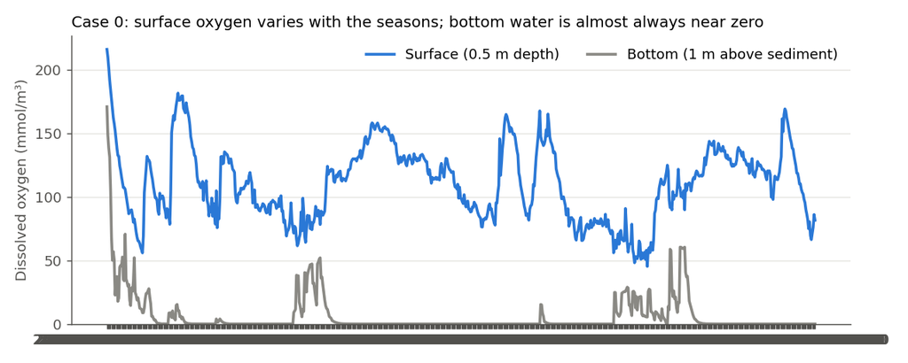

Figure 1. Surface and bottom dissolved oxygen in the base case.

### Tasks

- Run the `TropicalReservoir_0_Base` model and watch the temperature and oxygen plots develop.
- Open `output/WQ_0.csv` (surface) and `output/WQ_1.csv` (bottom) and plot `OXY_oxy` from both on one graph.
- Change `Fsed_oxy` in `&aed_oxygen` from -20 to -5, re-run the model and compare the bottom oxygen with your first run. Copy the `output` folder before re-running, and set `Fsed_oxy` back to -20 when you have finished.

### Questions

1. Why does the bottom water have almost no oxygen for most of the simulation? Use the words *stratification* and *sediment oxygen demand* in your answer. (Think back to Week 9.)
2. What happened to bottom oxygen when you reduced `Fsed_oxy` to -5? What does this tell you about the role of the sediment? (Think back to Week 2.)

## Case 1 — Add nutrients, organic matter and silica (`TropicalReservoir_1_Nutrients`)

### Set up the case folder

1. In `glm_casestudies`, copy the `TropicalReservoir_0_Base` folder, paste it into `glm_casestudies`, and rename the copy `TropicalReservoir_1_Nutrients`. Delete the `output` folder inside the new folder.
2. In `aed/aed.nml`, switch on the four nutrient modules in the `&aed_models` block by removing the `!` at the beginning of each corresponding line. Note the comma after `'aed_oxygen'` and no comma after `'aed_organic_matter'`:

   ```
   &aed_models
      models = 'aed_tracer',
              !'aed_noncohesive',
               'aed_oxygen',
              !'aed_carbon',
               'aed_silica',
               'aed_nitrogen',
               'aed_phosphorus',
               'aed_organic_matter'
              !'aed_phytoplankton',
              !'aed_zooplankton',
              !'aed_totals',
   /
   ```

3. In `aed/aed.nml`, in the `&aed_phosphorus` block, set `simPO4Adsorption = .false.` (phosphate adsorption needs the suspended solids module, which is off).
4. In `glm3.nml`, in the `&inflow` block:

   ```
      inflow_varnum = 14
      inflow_vars = 'FLOW','SAL','TEMP','OXY','SIL','AMM','NIT','FRP','DOC','POC','DON','PON','DOP','POP'
   ```

5. In `glm3.nml`, in the `&output` block:

   ```
      csv_point_nvars   = 12
      csv_point_vars    = 'temp','OXY_oxy','SIL_rsi','NIT_amm','NIT_nit','PHS_frp','OGM_doc','OGM_poc','OGM_don','OGM_pon','OGM_dop','OGM_pop'
   ```

6. In `plots_aed.nml`, replace the `&plots` block with:

   ```
   &plots
     nplots = 6
     plot_width = 300
     plot_height = 135
     title = 'Temperature (C)', 'Oxygen (mmol/m3)', 'Silica (mmol/m3)', 'NH4 (mmol/m3)', 'NO3 (mmol/m3)', 'FRP (mmol/m3)'
     vars  = 'temp', 'OXY_oxy', 'SIL_rsi', 'NIT_amm', 'NIT_nit', 'PHS_frp'
     min_z = 15, 0, 0, 0, 0, 0
     max_z = 35, 350, 5, 8, 8, 0.25
   /
   ```

With nutrients and organic matter on, but no algae to use them, surface phosphate (FRP) keeps rising from 0.02 to about 0.15 mmol/m³ by the end of the run. Ammonium and nitrate average about 4.4 mmol/m³ each. Mean surface oxygen falls from 110 to 81 mmol/m³, because the breakdown of organic matter uses oxygen.

The new modules add:

| Module | Main variables | Key processes and parameters |
| --- | --- | --- |
| `aed_silica` | `SIL_rsi` | Dissolved silica, used later by diatoms |
| `aed_nitrogen` | `NIT_amm`, `NIT_nit` | Nitrification (`Rnitrif = 0.1`/day), denitrification (`Rdenit = 0.26`/day), sediment release of NH₄ (`Fsed_amm = 1.3` mmol/m²/day) |
| `aed_phosphorus` | `PHS_frp` | Phosphate and atmospheric deposition. Adsorption is off (`simPO4Adsorption = .false.`) because there is no suspended solids module. |
| `aed_organic_matter` | `OGM_doc`, `OGM_poc`, `OGM_don`, `OGM_pon`, `OGM_dop`, `OGM_pop` | Particulate organic matter breaks down to dissolved organic matter, then is mineralised to NH₄ and FRP. This uses oxygen. |

The organic matter module links to the nutrient modules through its *target variables*. For example, `don_miner_product_variable = 'NIT_amm'` tells AED that mineralised organic nitrogen becomes ammonium. This is why `aed_organic_matter` is listed after nitrogen and phosphorus.

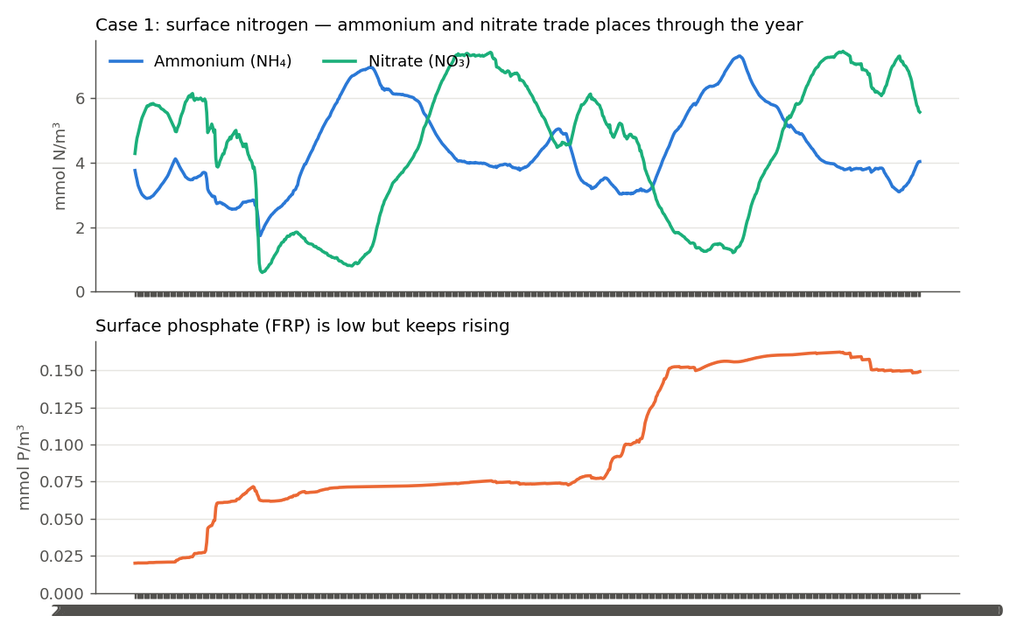

Figure 2. Surface ammonium and nitrate (top) and phosphate (bottom) in Case 1.

### Tasks

- Run the `TropicalReservoir_1_Nutrients` model. The plot window now also shows silica, NH₄, NO₃ and FRP.
- Open `output/WQ_0.csv` and `output/WQ_1.csv` and plot `NIT_amm`, `NIT_nit` and `PHS_frp` at the surface and the bottom.
- Compare the surface and bottom oxygen with Case 0 (`TropicalReservoir_0_Base/output/WQ_0.csv` and `WQ_1.csv`).

### Questions

1. How does the mean oxygen concentration at the surface and at the bottom change after organic matter was introduced? Explain the processes responsible for these changes.

## Case 2 — Add diatoms (`TropicalReservoir_2_Diatom`)

### Set up the case folder

1. In `glm_casestudies`, copy the `TropicalReservoir_1_Nutrients` folder, paste it into `glm_casestudies`, and rename the copy `TropicalReservoir_2_Diatom`. Delete the `output` folder inside the new folder.
2. In `aed/aed.nml`, switch on `'aed_phytoplankton'` in the `&aed_models` block. Add a comma after `'aed_organic_matter'`:

   ```
   &aed_models
      models = 'aed_tracer',
              !'aed_noncohesive',
               'aed_oxygen',
              !'aed_carbon',
               'aed_silica',
               'aed_nitrogen',
               'aed_phosphorus',
               'aed_organic_matter',
               'aed_phytoplankton'
              !'aed_zooplankton',
              !'aed_totals',
   /
   ```

3. In `aed/aed.nml`, go to the `&aed_phytoplankton` block and choose only one group. The numbers in `the_phytos` are column positions in the parameter database `aed/aed_phyto_pars.nml`; column 7 is the diatom. Change these four lines and leave the rest of the block as it is:

   ```
   &aed_phytoplankton
     num_phytos   =   1
     the_phytos   =   7
     settling     =   1
     ...
     c_uptake_target_variable    =''          ! the carbon module is off
     ...
   /
   ```

4. In `glm3.nml`, in the `&inflow` block:

   ```
      inflow_varnum = 17
      inflow_vars = 'FLOW','SAL','TEMP','OXY','SIL','AMM','NIT','FRP','DOC','POC','DON','PON','DOP','POP','DIA','DIA_IN','DIA_IP'
   ```

5. In `glm3.nml`, in the `&output` block:

   ```
      csv_point_nvars   = 13
      csv_point_vars    = 'temp','OXY_oxy','SIL_rsi','NIT_amm','NIT_nit','PHS_frp','OGM_doc','OGM_poc','OGM_don','OGM_pon','OGM_dop','OGM_pop','PHY_diatom'
   ```

6. In `plots_aed.nml`, replace the `&plots` block with:

   ```
   &plots
     nplots = 7
     plot_width = 300
     plot_height = 135
     title = 'Temperature (C)', 'Oxygen (mmol/m3)', 'Silica (mmol/m3)', 'NH4 (mmol/m3)', 'NO3 (mmol/m3)', 'FRP (mmol/m3)', 'Diatoms (mmol C/m3)'
     vars  = 'temp', 'OXY_oxy', 'SIL_rsi', 'NIT_amm', 'NIT_nit', 'PHS_frp', 'PHY_diatom'
     min_z = 15, 0, 0, 0, 0, 0, 0
     max_z = 35, 350, 5, 8, 8, 0.25, 5
   /
   ```

On their own, diatoms barely grow in this reservoir. Their biomass stays near 0.04 mmol C/m³ and peaks at only 0.8 mmol C/m³ in March 2012. The water is warmer than the diatom optimum on 88% of days, and there is very little phosphate.

The other lines of the `&aed_phytoplankton` block connect the phytoplankton to the other modules:

```
  p1_uptake_target_variable   ='PHS_frp'
  n1_uptake_target_variable   ='NIT_nit'
  n2_uptake_target_variable   ='NIT_amm'
  si_uptake_target_variable   ='SIL_rsi'
```

The `*_target_variable` lines link phytoplankton dynamics to variables from other modules. Algae use FRP, nitrate, and ammonium as nutrients for growth. When they release organic material or die, the carbon, nitrogen, and phosphorus they contain enter the organic matter pools (`OGM_doc`, `OGM_pon`, and others).

Open `aed_phyto_pars.nml` and look at column 7 (`'diatom'`). The most important parameters are:

| Parameter | Diatom value | Meaning |
| --- | --- | --- |
| `R_growth` | 1.8 /day | Maximum growth rate at 20 °C |
| `T_opt` / `T_max` | 24 / 32 °C | Optimum and maximum temperature for growth |
| `I_K` | 10 µE/m²/s | Light half-saturation (low = good in dim light) |
| `K_P` / `K_N` | 0.3 / 0.156 mmol/m³ | Half-saturation for phosphorus and nitrogen uptake |
| `R_resp` | 0.19 /day | Respiration and loss rate |
| `simSiUptake` | 0 | Silica limitation is switched off |

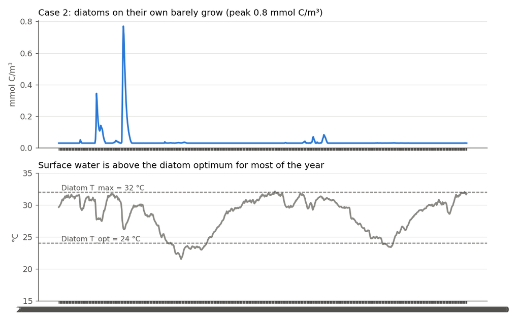

Figure 3. Surface diatom biomass (top) and surface temperature compared with the diatom optimum and maximum temperatures (bottom).

### Tasks

- Run the `TropicalReservoir_2_Diatom` model and watch where in the water column the diatoms grow.
- Before each new run, copy the `output` folder (for example to `output_baseline`), because every run overwrites `WQ_0.csv` and `WQ_1.csv`.
- **Increase the growth rate.** Open `aed/aed_phyto_pars.nml` and find the `pd%R_growth` line. Change the value in column 7 (diatom) from 1.8 to 3.6, then re-run. Compare diatom biomass (`PHY_diatom`) and nutrients (`NIT_amm`, `NIT_nit`, `PHS_frp`) at the surface (`WQ_0.csv`) and the bottom (`WQ_1.csv`) with your baseline run.
- **Reduce the half-saturation constants.** Set `R_growth` back to 1.8. In column 7, change `K_N` from 0.156 to 0.0156 and `K_P` from 0.3 to 0.03, then re-run. Compare biomass and nutrients at the surface and the bottom again.
- Set `K_N` and `K_P` back to their original values when you have finished.

### Questions

1. How does diatom biomass change when you increase the growth rate (`R_growth`), and when you reduce `K_N` and `K_P`? How do the nutrient concentrations change at the surface and the bottom? Make plots of biomass and nutrients for the three runs to support your answer.

## Case 3 — Three phyto groups (`TropicalReservoir_3_ThreePhyto`)

### Set up the case folder

1. In `glm_casestudies`, copy the `TropicalReservoir_2_Diatom` folder, paste it into `glm_casestudies`, and rename the copy `TropicalReservoir_3_ThreePhyto`. Delete the `output` folder inside the new folder.
2. The module list is the same as Case 2. In `aed/aed.nml`, change only the first three lines of the `&aed_phytoplankton` block to use three columns of the database:

   ```
   &aed_phytoplankton
     num_phytos   =   3
     the_phytos   =   3,7,8      ! green, diatom, cyano
     settling     =   1,1,4      ! cyano uses buoyancy control
     ...
   /
   ```

3. In `glm3.nml`, in the `&inflow` block:

   ```
      inflow_varnum = 23
      inflow_vars = 'FLOW','SAL','TEMP','OXY','SIL','AMM','NIT','FRP','DOC','POC','DON','PON','DOP','POP','GRN','GRN_IN','GRN_IP','DIA','DIA_IN','DIA_IP','CRY','CRY_IN','CRY_IP'
   ```

4. In `glm3.nml`, in the `&output` block:

   ```
      csv_point_nvars   = 15
      csv_point_vars    = 'temp','OXY_oxy','SIL_rsi','NIT_amm','NIT_nit','PHS_frp','OGM_doc','OGM_poc','OGM_don','OGM_pon','OGM_dop','OGM_pop','PHY_green','PHY_diatom','PHY_cyano'
   ```

5. In `plots_aed.nml`, replace the `&plots` block with:

   ```
   &plots
     nplots = 8
     plot_width = 300
     plot_height = 135
     title = 'Temperature (C)', 'Oxygen (mmol/m3)', 'NH4 (mmol/m3)', 'NO3 (mmol/m3)', 'FRP (mmol/m3)', 'Diatoms (mmol C/m3)', 'Green Algae (mmol C/m3)', 'Cyanobacteria (mmol C/m3)'
     vars  = 'temp', 'OXY_oxy', 'NIT_amm', 'NIT_nit', 'PHS_frp', 'PHY_diatom', 'PHY_green', 'PHY_cyano'
     min_z = 15, 0, 0, 0, 0, 0, 0, 0
     max_z = 35, 350, 8, 8, 0.25, 5, 60, 60
   /
   ```

Under competition, diatoms are largely outcompeted by green algae and cyanobacteria. The overall phytoplankton population increases, which in turn draws down surface phosphate concentrations. As phosphate becomes scarce, phosphorus limitation begins to constrain phytoplankton growth.

`settling = 4` lets cyanobacteria change their density between `min_rho` and `max_rho` (900 and 1200 kg/m³, set at the end of the `&aed_phytoplankton` block). This means they can float up to the light, like real *Microcystis* or *Dolichospermum*.

Compare the three groups in `aed_phyto_pars.nml` (columns 3, 7 and 8):

| Parameter | Green | Diatom | Cyano | What it favours |
| --- | --- | --- | --- | --- |
| `R_growth` (/day) | 1.5 | 1.8 | 1.25 | Fast growth when conditions are good |
| `T_opt` (°C) | 26 | 24 | 34 | Hot tropical surface water favours cyano |
| `T_max` (°C) | 36 | 32 | 40 | Diatoms are stressed above 30 °C |
| `I_K` (µE/m²/s) | 25 | 10 | 50 | Diatoms cope best with low light |
| `K_P` (mmol/m³) | 0.12 | 0.30 | 0.35 | Greens win when phosphate is scarce |
| `R_resp` (/day) | 0.09 | 0.19 | 0.11 | Diatoms lose the most biomass each day |
| `p0` (mmol C/m³) | 2 | 0.03 | 1 | Minimum biomass kept in the water |

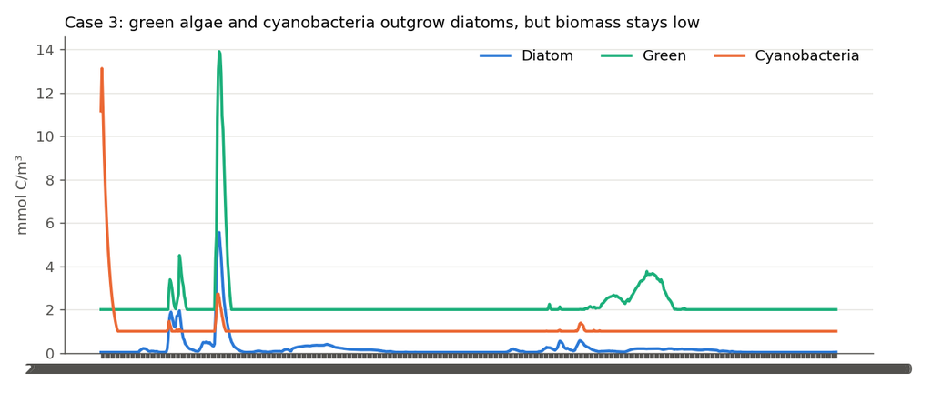

Figure 4. Surface biomass of the three phytoplankton groups in Case 3.

### Tasks

- Run the `TropicalReservoir_3_ThreePhyto` model. The plot window shows all three groups side by side.
- Make a stacked area plot of `PHY_green`, `PHY_diatom` and `PHY_cyano` from `output/WQ_0.csv` to show how each contributes to total biomass.

### Questions

1. What is the dominant phytoplankton group, and why is it dominant? Use the parameter table to support your answer.

## Case 4 — Nutrient load scenarios (`TropicalReservoir_4_HighNutrientLoad`)

### Set up the case folder

1. In `glm_casestudies`, copy the `TropicalReservoir_3_ThreePhyto` folder, paste it into `glm_casestudies`, and rename the copy `TropicalReservoir_4_HighNutrientLoad`. Delete the `output` folder inside the new folder.
2. Open `bcs/inflow_WQ.csv` in Excel and multiply the values in the following columns by 5: `AMM`, `NIT`, `FRP`, `FRP_ADS`, `DON`, `PON`, `DOP` and `POP`. Before you close the file, make sure the `time` column is in the right format (`yyyy-mm-dd hh:mm:ss`).
3. No changes are needed in `aed.nml`, `glm3.nml` or `plots_aed.nml`.

In this case we increase the nutrient load coming from the catchment and look at how the nutrient concentrations in the reservoir and the phytoplankton respond. The baseline for comparison is Case 3.

The mean inflow concentrations become:

| Inflow column | Baseline (mmol/m³) | Load × 5 (mmol/m³) |
| --- | --- | --- |
| `AMM` (ammonium) | 1.44 | 7.19 |
| `NIT` (nitrate) | 0.32 | 1.59 |
| `FRP` (phosphate) | 0.23 | 1.13 |
| `DON` (dissolved organic N) | 19.6 | 97.8 |
| `DOP` (dissolved organic P) | 0.17 | 0.84 |

### Tasks

- Run the `TropicalReservoir_4_HighNutrientLoad` model and compare its plot window with Case 3.
- Make your own scenario: copy the `TropicalReservoir_3_ThreePhyto` folder, rename the copy (for example `TropicalReservoir_4_Load10`), delete its `output` folder, scale the nutrients by 2 or 10 instead of 5, and run it.
- Try scaling only phosphorus (`FRP`, `DOP`, `POP`) or only nitrogen (`AMM`, `NIT`, `DON`, `PON`).

### Questions

1. How do the nutrient concentrations in the water change when the nutrient load increases? Make plots of the nutrient variables (`NIT_amm`, `NIT_nit`, `PHS_frp`, `OGM_don`, `OGM_dop`) at the surface (`WQ_0.csv`) and the bottom (`WQ_1.csv`) for Case 3 and Case 4.
2. How does the phytoplankton respond to the increase in nutrient load?
3. (Optional) What level of nutrient loading triggers an algal bloom? You may need to test additional scaling factors to answer this question. A scatter plot of nutrient loading against peak chlorophyll-a concentration can help you visualise this relationship and identify a possible threshold.

## Case 5 — Add zooplankton optional (`TropicalReservoir_5_Zooplankton`)

### Set up the case folder

1. In `glm_casestudies`, copy the `TropicalReservoir_3_ThreePhyto` folder, paste it into `glm_casestudies`, and rename the copy `TropicalReservoir_5_Zooplankton`. Delete the `output` folder inside the new folder. Copy from Case 3, not Case 4, so the inflow nutrients are not multiplied.
2. In `aed/aed.nml`, switch on `'aed_zooplankton'` in the `&aed_models` block. Add a comma after `'aed_phytoplankton'`:

   ```
   &aed_models
      models = 'aed_tracer',
              !'aed_noncohesive',
               'aed_oxygen',
              !'aed_carbon',
               'aed_silica',
               'aed_nitrogen',
               'aed_phosphorus',
               'aed_organic_matter',
               'aed_phytoplankton',
               'aed_zooplankton'
              !'aed_totals',
   /
   ```

3. In `glm3.nml`, in the `&inflow` block:

   ```
      inflow_varnum = 24
      inflow_vars = 'FLOW','SAL','TEMP','OXY','SIL','AMM','NIT','FRP','DOC','POC','DON','PON','DOP','POP','GRN','GRN_IN','GRN_IP','DIA','DIA_IN','DIA_IP','CRY','CRY_IN','CRY_IP','ZOO'
   ```

4. In `glm3.nml`, in the `&output` block:

   ```
      csv_point_nvars   = 16
      csv_point_vars    = 'temp','OXY_oxy','SIL_rsi','NIT_amm','NIT_nit','PHS_frp','OGM_doc','OGM_poc','OGM_don','OGM_pon','OGM_dop','OGM_pop','PHY_green','PHY_diatom','PHY_cyano','ZOO_zoo01'
   ```

5. In `plots_aed.nml`, replace the `&plots` block with:

   ```
   &plots
     nplots = 9
     plot_width = 300
     plot_height = 135
     title = 'Temperature (C)', 'Oxygen (mmol/m3)', 'NH4 (mmol/m3)', 'NO3 (mmol/m3)', 'FRP (mmol/m3)', 'Diatoms (mmol C/m3)', 'Green Algae (mmol C/m3)', 'Cyanobacteria (mmol C/m3)', 'Zooplankton (mmol C/m3)'
     vars  = 'temp', 'OXY_oxy', 'NIT_amm', 'NIT_nit', 'PHS_frp', 'PHY_diatom', 'PHY_green', 'PHY_cyano', 'ZOO_zoo01'
     min_z = 15, 0, 0, 0, 0, 0, 0, 0, 0
     max_z = 35, 350, 8, 8, 0.25, 5, 60, 60, 1
   /
   ```

This case is optional. It adds one zooplankton group to Case 3, grazing on the three phytoplankton groups. With the supplied parameters, the zooplankton cannot sustain itself: it falls from 0.5 to its minimum of 0.01 mmol C/m³ within the first weeks.

The `&aed_zooplankton` block chooses group 1 from the zooplankton database and sends its waste to the organic matter pools:

```
&aed_zooplankton
   num_zoops = 1
   the_zoops = 1
   dn_target_variable = 'OGM_don'
   pn_target_variable = 'OGM_pon'
   dp_target_variable = 'OGM_dop'
   pp_target_variable = 'OGM_pop'
   dc_target_variable = 'OGM_doc'
   pc_target_variable = 'OGM_poc'
   dbase='aed/aed_zoop_pars.nml'
/
```

In `aed_zoop_pars.nml`, column 1 (`zoo01`) grazes on three prey, with a preference for each:

```
  zoop_param%num_prey          = 3
  zoop_param%prey(1)%zoop_prey = 'PHY_green',   Pzoo_prey = 0.4
  zoop_param%prey(2)%zoop_prey = 'PHY_diatom',  Pzoo_prey = 0.1
  zoop_param%prey(3)%zoop_prey = 'PHY_cyano',   Pzoo_prey = 0.5
```

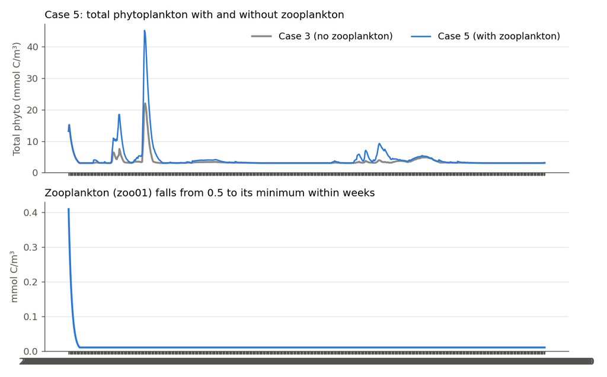

Figure 5. Total phytoplankton with and without zooplankton (top), and zooplankton biomass (bottom).

## Final submission

Submit one document that contains:

- **Answers to all questions** in Cases 0–4, numbered by case and question (for example, Case 2 – Q1).
- **The plots listed below.** Each plot needs a figure number, a caption, axis labels with units, and a legend when it shows more than one line.

### Plots to submit

| Plot | Case | What to plot |
| --- | --- | --- |
| 1 | Case 0 | Bottom oxygen with `Fsed_oxy` = -20 and -5 |
| 2 | Case 1 | Oxygen at the surface and the bottom, Case 0 compared with Case 1 |
| 3 | Case 2 | Diatom biomass (`PHY_diatom`) at the surface and the bottom for the baseline and `R_growth` = 3.6 runs |
| 4 | Case 2 | Nutrients (`NIT_amm`, `NIT_nit`, `PHS_frp`) at the surface and the bottom for the baseline, `R_growth` = 3.6, and reduced `K_N`/`K_P` runs |
| 5 | Case 3 | Stacked area plot of green algae, diatoms and cyanobacteria at the surface |
| 6 | Case 4 | Phosphate (`PHS_frp`) and nitrate (`NIT_nit`) at the surface and the bottom, Case 3 compared with Case 4 |
| 7 | Case 4 | Green algae, diatoms and cyanobacteria at the surface and the bottom, Case 3 compared with Case 4 |

Case 5 (zooplankton) is optional and does not need to be submitted.